# Bayesian_Zero_inflated_negative_binomia_Regression

liu_weibiao

2024-10-02

```r
library(tidyverse)        # ggplot, dplyr, %>%, and friends
library(brms)             # Bayesian modeling through Stan
library(rstan)             # Bayesian modeling through Stan
library(marginaleffects)  # Calculate marginal effects for regression models
library(tidybayes)        # Manipulate Stan objects in a tidy way
library(patchwork)        # Combine ggplot objects
library(ggrepel)          # Automatically position labels
library(scales)           # Format numbers in nice ways
library(collapse)
library(broom)            # Convert model objects to data frames
library(broom.mixed)      # Convert brms model objects to data frames
library(extraDistr)       # Use extra distributions like dprop()
library(ggdist)           # Special geoms for posterior distributions
library(gghalves)         # Special half geoms
library(ggbeeswarm)       # Special distribution-shaped point jittering
library(modelsummary)     # Create side-by-side regression tables
library(ggthemes)
library(wesanderson)
library(gridExtra)        # Merge Graphs
library(bayesplot)
library(glue)
```

### Country-level

Country-level relationship between proportion of sample and socioeconomic/cultural factors for traditional studies (using PS2014 as an example) and big team science (using PSA 001 as an example)

### Taking GDP per capita as an example

# 1 View data

```r
gdpdata <- read_csv("gdpdata.csv")%>%
  mutate(log_GDP_per_capita = log(GDP_per_capita))%>% #Log Transformations
  mutate(log_bts_sample_size = log(bts_sample_size))  %>% #Log Transformations
  mutate(log_ps_sample_size = log(ps))   #Log Transformations
gdpdata
```

```
## # A tibble: 185 × 13
##    country_3 country_2 continent     GDP_per_capita bts_sample_size total_bts
##    <chr>     <chr>     <chr>                  <dbl>           <dbl>     <dbl>
##  1 AND       AD        Europe                 42.0                0     11484
##  2 ARE       AE        Asia                   53.8               80     11484
##  3 ATG       AG        North America          18.7                0     11484
##  4 ARM       AM        Asia                    7.01               0     11484
##  5 AGO       AO        Africa                  3.00               0     11484
##  6 ARG       AR        South America          13.7               91     11484
##  7 AUT       AT        Europe                 52.1              236     11484
##  8 AUS       AU        Oceania                64.5              885     11484
##  9 AZE       AZ        Asia                    7.74               0     11484
## 10 BIH       BA        Europe                  7.59               0     11484
## # ℹ 175 more rows
## # ℹ 7 more variables: percentage_sample <dbl>, ps <dbl>, total_ps <dbl>,
## #   ps2014 <dbl>, log_GDP_per_capita <dbl>, log_bts_sample_size <dbl>,
## #   log_ps_sample_size <dbl>
```

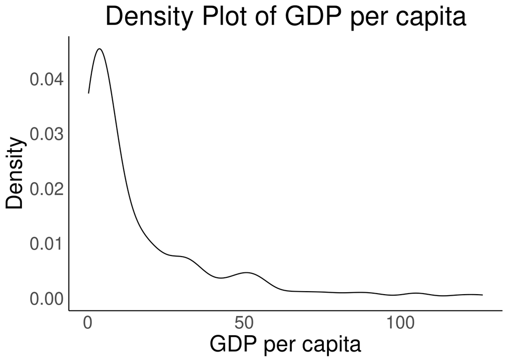

```r
#Observe the distribution of independent variables
ggplot(gdpdata, aes(x = GDP_per_capita)) +
  geom_density() +
  labs(title = "Density Plot of GDP per capita", x = "GDP per capita", y = "Density") +
    theme_bw() +
  theme_minimal()+
  theme(
    text = element_text(size = 22),
    plot.title = element_text(hjust = .5),
    panel.grid.major = element_blank(),
    panel.grid.minor = element_blank(),
    panel.border = element_blank(),
    strip.background =element_blank(),
    axis.line.x.bottom = element_line(color = 'black'),
    axis.line.y.left   = element_line(color = 'black'),
    legend.position = "none")
```

```r
#Normality test
shapiro.test(gdpdata$GDP_per_capita)
```

```
##
##  Shapiro-Wilk normality test
##
## data:  gdpdata$GDP_per_capita
## W = 0.7041, p-value < 2.2e-16
```

By examining the distribution map and the normality test, it can be seen that the distribution of the independent variables is not normal.Therefore, Therefore, we performed logarithmic transformation on the data of GDP per capita.

The data distribution of GDP per capita after logarithmic transformation is as follows

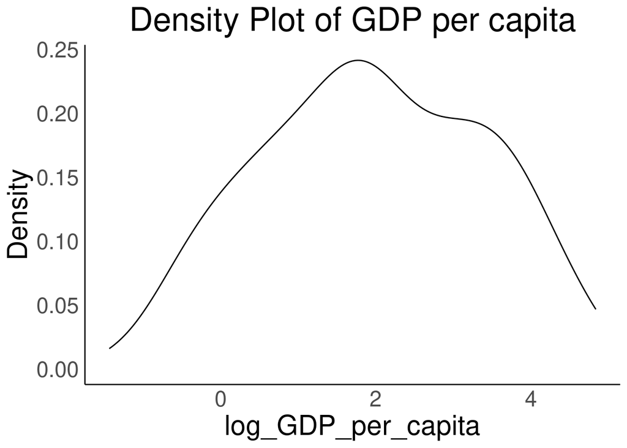

```r
#Observe the distribution of independent variables
ggplot(gdpdata, aes(x = log_GDP_per_capita)) +
  geom_density() +
  labs(title = "Density Plot of GDP per capita", x = "log_GDP_per_capita", y = "Density") +
    theme_bw() +
  theme_minimal()+
  theme(
    text = element_text(size = 22),
    plot.title = element_text(hjust = .5),
    panel.grid.major = element_blank(),
    panel.grid.minor = element_blank(),
    panel.border = element_blank(),
    strip.background =element_blank(),
    axis.line.x.bottom = element_line(color = 'black'),
    axis.line.y.left   = element_line(color = 'black'),
    legend.position = "none")
```

```r
shapiro.test(gdpdata$log_GDP_per_capita)
```

```
##
##  Shapiro-Wilk normality test
##
## data:  gdpdata$log_GDP_per_capita
## W = 0.98238, p-value = 0.01969
```

The sample size is the dependent variable, which is a simple count data that contains many zeros, and non-zero data has over-dispersion. To diagnose overdispersion of count data, we used the model comparison leaf one out cross validation (LOO-CV) method to compare the zero-inflation Poisson model with the zero-inflation negative binomial regression [Winter & Bürkner, 2021](https://doi.org/10.1111/lnc3.12439).

```r
gdp_zero_inflated_poisson_bts <- brms::brm(
   bf(bts_sample_size ~ 1 + log_GDP_per_capita,
      zi ~ 1 + log_GDP_per_capita ),
  data = gdpdata,
  family = zero_inflated_poisson(),
  chains = 4, iter = 20000, warmup = 10000,
  cores = 4, seed = 1234,

  save_pars = save_pars(all = TRUE),
  control = list(adapt_delta = 0.99,  max_treedepth=10),
  backend = "cmdstanr",
  file = "gdp_zero_inflated_poisson_bts"
)
gdp_zero_inflated_poisson_bts
```

```
##  Family: zero_inflated_poisson
##   Links: mu = log; zi = logit
## Formula: bts_sample_size ~ 1 + log_GDP_per_capita
##          zi ~ 1 + log_GDP_per_capita
##    Data: gdpdata (Number of observations: 185)
##   Draws: 4 chains, each with iter = 20000; warmup = 10000; thin = 1;
##          total post-warmup draws = 40000
##
## Regression Coefficients:
##                       Estimate Est.Error l-95% CI u-95% CI Rhat Bulk_ESS
## Intercept                 4.15      0.04     4.07     4.22 1.00    15714
## zi_Intercept              3.13      0.48     2.25     4.12 1.00    16850
## log_GDP_per_capita        0.45      0.01     0.43     0.47 1.00    16463
## zi_log_GDP_per_capita    -0.81      0.16    -1.14    -0.50 1.00    18963
##                       Tail_ESS
## Intercept                18653
## zi_Intercept             18145
## log_GDP_per_capita       20710
## zi_log_GDP_per_capita    20233
##
## Draws were sampled using sample(hmc). For each parameter, Bulk_ESS
## and Tail_ESS are effective sample size measures, and Rhat is the potential
## scale reduction factor on split chains (at convergence, Rhat = 1).
```

```r
gdp_zero_inflated_negbinomial_bts <- brms::brm(
   bf(bts_sample_size ~ 1 + log_GDP_per_capita,
      zi ~ 1 + log_GDP_per_capita ),
  data = gdpdata,
  family = zero_inflated_negbinomial(),
  chains = 4, iter = 20000, warmup = 10000,
  cores = 4, seed = 1234,

  save_pars = save_pars(all = TRUE),
  control = list(adapt_delta = 0.99,  max_treedepth=10),
  backend = "cmdstanr",
  file = "gdp_zero_inflated_negbinomial_bts"
)
gdp_zero_inflated_negbinomial_bts
```

```
##  Family: zero_inflated_negbinomial
##   Links: mu = log; shape = identity; zi = logit
## Formula: bts_sample_size ~ 1 + log_GDP_per_capita
##          zi ~ 1 + log_GDP_per_capita
##    Data: gdpdata (Number of observations: 185)
##   Draws: 4 chains, each with iter = 20000; warmup = 10000; thin = 1;
##          total post-warmup draws = 40000
##
## Regression Coefficients:
##                       Estimate Est.Error l-95% CI u-95% CI Rhat Bulk_ESS
## Intercept                 4.46      0.39     3.72     5.24 1.00    20582
## zi_Intercept              3.13      0.48     2.24     4.12 1.00    23537
## log_GDP_per_capita        0.36      0.12     0.12     0.59 1.00    22791
## zi_log_GDP_per_capita    -0.81      0.16    -1.14    -0.50 1.00    26396
##                       Tail_ESS
## Intercept                20178
## zi_Intercept             22143
## log_GDP_per_capita       24238
## zi_log_GDP_per_capita    23653
##
## Further Distributional Parameters:
##       Estimate Est.Error l-95% CI u-95% CI Rhat Bulk_ESS Tail_ESS
## shape     1.36      0.29     0.86     1.98 1.00    28237    23928
##
## Draws were sampled using sample(hmc). For each parameter, Bulk_ESS
## and Tail_ESS are effective sample size measures, and Rhat is the potential
## scale reduction factor on split chains (at convergence, Rhat = 1).
```

```r
loo_poisson <- loo(gdp_zero_inflated_poisson_bts, moment_match = TRUE)
```

```
## Recompiling the model with 'rstan'
```

[output not shown]

```
## Recompilation done
```

```r
loo_negbinomial <- loo(gdp_zero_inflated_negbinomial_bts, moment_match = TRUE)
```

```
## Recompiling the model with 'rstan'
```

[output not shown]

```
## Recompilation done
```

```r
loo <-  brms::loo_compare(loo_poisson, loo_negbinomial)
loo
```

```
##                                   elpd_diff se_diff
## gdp_zero_inflated_negbinomial_bts     0.0       0.0
## gdp_zero_inflated_poisson_bts     -5872.8    3133.1
```

The results show that the zero inflation Poisson model fits worse (elpd-diff = -5872.8, se-diff = 3133.1), indicating that the data are overdispersion. Therefore, Bayesian zero-inflated negative binomial regression is appropriate to process the data.

# 2 Regression model

Due to the fact that the dependent variable is simply counted data, contains many zeros and has excessive dispersion, we will use zero-inflated negative binomial regression to fit the data.

## 2.1 Zero-inflated negative binomial regression

### The formula of zero-inflated negative binomial distribution

$$P(Y = y) =
\begin{cases}
p + (1 - p) \left(1 + \frac{\mu}{\phi}\right)^{-\phi}, & y = 0 \\
(1 - p) \frac{\Gamma(y + \phi)}{y! \Gamma(\phi)} \left(1 +
\frac{\mu}{\phi}\right)^{-\phi} \left(1 + \frac{\phi}{\mu}\right)^{-y},
& y = 1, 2, \ldots
\end{cases}$$

```r
priors_main <- get_prior(
bf(bts_sample_size ~ log_GDP_per_capita,
zi ~ log_GDP_per_capita),
  data = gdpdata,
  family = zero_inflated_negbinomial(),
  chains = 4, iter = 20000, warmup = 10000,
  cores = 4, seed = 1234,

  backend = "cmdstanr")
priors_main
```

```
##                    prior     class               coef group resp dpar nlpar lb
##                   (flat)         b
##                   (flat)         b log_GDP_per_capita
##  student_t(3, -2.3, 2.5) Intercept
##        gamma(0.01, 0.01)     shape                                           0
##                   (flat)         b                                 zi
##                   (flat)         b log_GDP_per_capita              zi
##           logistic(0, 1) Intercept                                 zi
##  ub       source
##          default
##     (vectorized)
##          default
##          default
##          default
##     (vectorized)
##          default
```

## 3.1 Set the prior of shape(ϕ)

For the shape parameters in Bayesian negative binomial regression, an inv_gamma(0.4, 0.3) prior is appropriate, as it can cover a broader range (Bürkner, 2024; https://github.com/paul-buerkner/brms/issues/1614). Therefore, we will also use an inv_gamma (0.4, 0.3) prior for the shape parameters in our Bayesian zero-inflated negative binomial regression model.

## 3.2 Set the prior of β0

Based on the self-compiled big team science data, the total sample size, after filtering according to our operational definition, ranges from 1,100,000 to 1,200,000. To ensure that the intercept β₀ can cover all possible ranges from 1 to 1,200,000, we consider two priors: a more diffuse prior, β₀ ~ Normal (0, 4.67), and a more concentrated prior, β₀ ~ Normal (6, 2.67).

Using the properties of the log-normal distribution, the β₀ ~ Normal (0, 4.67) prior covers a range from about 8.23e-07 (e^(0-4.67×3)) to 1,214,691 (e^(0+4.67×3)), while the β₀ ~ Normal (6, 2.67) prior ranges from about 0.13 (e^(6-2.67×3)) to 1,214,691 (e^(6+2.67×3)). Both priors effectively cover the target range of 1 to 1,200,000.

We have made a visual comparison between the intercept priors β₀ ~ Normal (6, 2.67) and β₀ ~ Normal (0, 4.67) (see figure below).

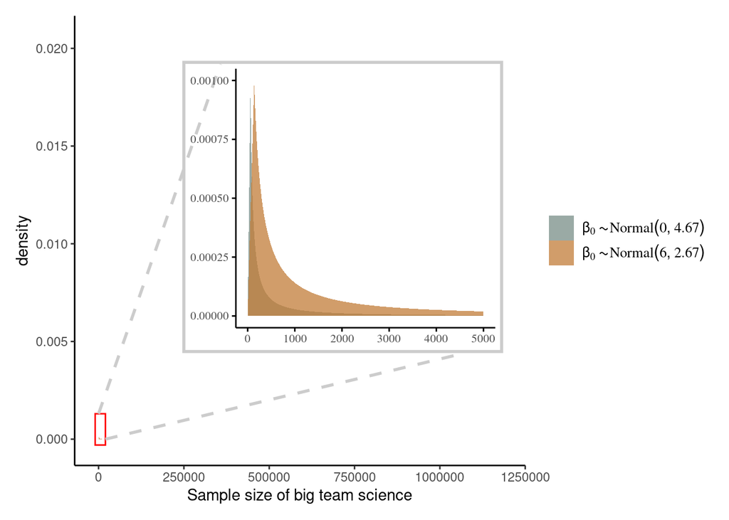

```r
x_zoom_range <- c(0, 5000)
y_zoom_range <- c(0, 0.001)

# 创建主数据，使用表达式格式的 group 标签
main_data <- tibble(x = c(400, 600),
                    y = c(0.00062, 0.00054),
                    meanlog = c(0, 6),
                    sdlog = c(4.67, 2.67)) %>%
  expand_grid(number = seq(from = 0, to = 1190000, length.out = 300000)) %>%
  mutate(
    density = dlnorm(number, meanlog, sdlog),
    group_label = glue("beta[0] %~% Normal({meanlog}, {sdlog})"),
    group = factor(group_label, levels = unique(group_label))
  )

# 主图
main_plt <- main_data %>%
  ggplot(aes(fill = group, color = group)) +
  geom_area(aes(x = number, y = density),
            alpha = 3/4, linewidth = 0, position = "identity") +
  scale_fill_manual(
    values = wesanderson::wes_palette("Moonrise2")[1:2],
    labels = parse_format()
  ) +
  scale_color_manual(
    values = wesanderson::wes_palette("Moonrise2")[1:2],
    labels = parse_format()
  ) +


  xlab("Sample size of big team science")+
  annotate("rect",
           xmin = -10000, xmax =20000,
           ymin = -0.0003, ymax = 0.0013,
           color = "red", linetype = "solid", fill = NA, size = 0.5) +
  annotate("segment", x = 0, y = 0.0013, xend = 1190000 * 0.3, yend = 0.02 * 0.96,
           color = "grey80", linetype = "dashed", size = 1) +
  annotate("segment", x = 20000, y = 0, xend = 1190000 * 0.9, yend = 0.02 * 0.22,
           color = "grey80", linetype = "dashed", size = 1) +
  theme(
    panel.grid = element_blank(),
    panel.border = element_blank(),
    panel.background = element_blank(),
    axis.line.x = element_line(color = "black"),
    axis.line.y = element_line(color = "black"),
    legend.title = element_blank(),
    legend.text = element_text(family = "Times", size = 10)
  )
# 缩放图数据
zoom_data <- main_data %>% filter(number <= 5000)

# 缩放图
zoom_plt <- zoom_data %>%
  ggplot(aes(fill = group, color = group)) +
  geom_area(aes(x = number, y = density),
            alpha = 3/4, linewidth = 0, position = "identity") +
  scale_fill_manual(values = wesanderson::wes_palette("Moonrise2")[1:2]) +
  scale_color_manual(values = wesanderson::wes_palette("Moonrise2")[1:2]) +
  scale_y_continuous(limits = y_zoom_range) +
  scale_x_continuous(limits = x_zoom_range) +
  theme_minimal(base_family = "Times") +
  theme(
    plot.background = element_rect(fill = NA, color = "grey80", size = 2),
    legend.position = "none",
    aspect.ratio = 1,
    panel.grid = element_blank(),
    panel.border = element_blank(),
    panel.background = element_blank(),
    axis.title = element_blank(),
    axis.text = element_text(size = 8),
    axis.ticks = element_line(color = "black"),
    axis.line.x = element_line(color = "black"),
    axis.line.y = element_line(color = "black")
  )
# 组合图
combined_plot <- main_plt +
  inset_element(zoom_plt,
                left = 0.2, bottom = 0.25,
                right = 0.99, top = 0.9)

# 显示图
combined_plot
```

```r
ggsave(filename = "pp1.pdf", plot = combined_plot, device = "pdf", width = 7, height = 4)
```

Notably, the prior β₀ ~ Normal (0, 4.67) is more extreme, with a median of e⁰ = 1, whereas the median for β₀ ~ Normal (6, 2.67) is e⁶ = 403.

## 3.3 The intercept γ0 of p_i

The probability of 0 in our data may be mostly concentrated between 0.1-0.9, and after logit transformation it is (-2.2, 2.2). We set γ0~Normal (0,1), which corresponds exactly to this range.

## 3.4 The slope β1 of μ_i and the slope γ1 of p_i

For the slope parameters β1 and γ1, we use the changing slope to plot the prior prediction distribution and then select the appropriate prior.

[figure not shown]

```r
set.seed(11)

generate_data_and_plot <- function(sd, title) {
  tibble(i = 1:100,
         a = rnorm(100, mean = 6, sd = 2.7)) %>%
    mutate(
      `beta[1]%~%Normal(0*', '*0.01)` = rnorm(100, mean = 0, sd = 0.01),
      `beta[1]%~%Normal(0*', '*0.05)` = rnorm(100, mean = 0, sd = 0.05),
      `beta[1]%~%Normal(0*', '*0.1)` = rnorm(100, mean = 0, sd = 0.1),
      `beta[1]%~%Normal(0*', '*1)` = rnorm(100, mean = 0, sd = 1),
      `beta[1]%~%Normal(0*', '*10)` = rnorm(100, mean = 0, sd = 10)) %>%
    pivot_longer(contains("beta"), values_to = "b", names_to = "prior") %>%
    expand_grid(x = seq(from = -1, to = 5, length.out = 100)) %>%
    mutate(lambda = exp(1 + a + b * x),
           pi = plogis(1 + rnorm(1, mean = 0, sd = 1) + rnorm(1, mean = 0, sd = sd) * x)) %>%
    rowwise() %>%
    mutate(shape_param = 1 / rgamma(1, shape = 0.4, rate = 0.3),
           y_nb = rnbinom(1, size = shape_param, mu = lambda),
           zero_inflated = rbinom(1, size = 1, prob = pi),
           y = ifelse(zero_inflated == 1, 0, y_nb)) %>%
    ggplot(aes(x = x, y = y, group = i)) +
    geom_line(linewidth = 1/4, alpha = 2/3, color = wes_palette("Moonrise2")[4]) +
    labs(x = "GDP_per_capita", y = "sample size", title = title) +
    coord_cartesian(ylim = c(0, 1200000)) +
    facet_wrap(~ prior, labeller = label_parsed)
}


pp1 <- generate_data_and_plot(0.01, expression(paste(gamma[1] %~% Normal(0*', '*0.01))))+theme(
    legend.position = "none",
    panel.grid.major = element_blank(),
    panel.grid.minor = element_blank(),
    panel.border = element_blank(),
    panel.background = element_blank(),
    axis.line.x = element_line(color = "black"),
    axis.line.y = element_line(color = "black")
  )
pp2 <- generate_data_and_plot(0.05, expression(paste(gamma[1] %~% Normal(0*', '*0.05))))+theme(
    legend.position = "none",
    panel.grid.major = element_blank(),
    panel.grid.minor = element_blank(),
    panel.border = element_blank(),
    panel.background = element_blank(),
    axis.line.x = element_line(color = "black"),
    axis.line.y = element_line(color = "black")
  )
pp3 <- generate_data_and_plot(0.1, expression(paste(gamma[1] %~% Normal(0*', '*0.1))))+theme(
    legend.position = "none",
    panel.grid.major = element_blank(),
    panel.grid.minor = element_blank(),
    panel.border = element_blank(),
    panel.background = element_blank(),
    axis.line.x = element_line(color = "black"),
    axis.line.y = element_line(color = "black")
  )
pp4 <- generate_data_and_plot(1, expression(paste(gamma[1] %~% Normal(0*', '*1))))+theme(
    legend.position = "none",
    panel.grid.major = element_blank(),
    panel.grid.minor = element_blank(),
    panel.border = element_blank(),
    panel.background = element_blank(),
    axis.line.x = element_line(color = "black"),
    axis.line.y = element_line(color = "black")
  )

pp <- gridExtra::grid.arrange(pp1, pp2, pp3, pp4, ncol = 1)
```

```r
ggsave(filename = "pp2.pdf", plot = pp, device = "pdf", width = 8, height = 18)
```

The prior selection can meet two criteria (as shown below): (1) it is within the possible range of values (there are values on the x-axis, and the sample size can take the larger value of 1,200,000); (2) the change in the data is not extreme.

Based on the above criteria, the priors we finally chose were β1 ~ Normal (0, 0.1) & γ1 ~ Normal (0, 0.1).

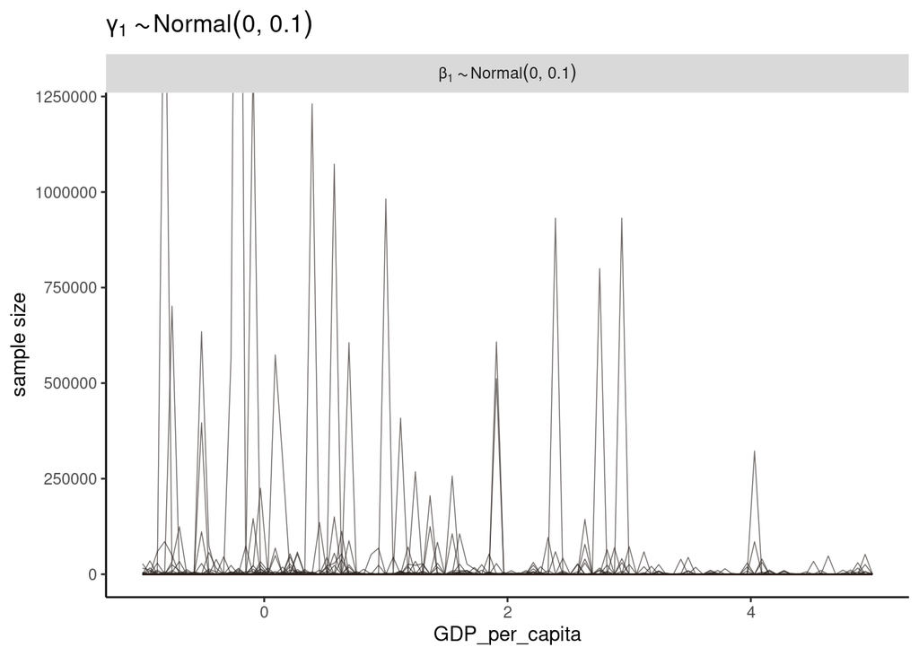

```r
set.seed(11)

generate_data_and_plot <- function(sd, title) {
  tibble(i = 1:100,
         a = rnorm(100, mean = 6, sd = 2.7)) %>%
    mutate( `beta[1]%~%Normal(0*', '*0.1)` = rnorm(100, mean = 0, sd = 0.1)) %>%
    pivot_longer(contains("beta"), values_to = "b", names_to = "prior") %>%
    expand_grid(x = seq(from = -1, to = 5, length.out = 100)) %>%
    mutate(lambda = exp(1 + a + b * x),
           pi = plogis(1 + rnorm(1, mean = 0, sd = 1) + rnorm(1, mean = 0, sd = sd) * x)) %>%
    rowwise() %>%
    mutate(shape_param = 1 / rgamma(1, shape = 0.4, rate = 0.3),
           y_nb = rnbinom(1, size = shape_param, mu = lambda),
           zero_inflated = rbinom(1, size = 1, prob = pi),
           y = ifelse(zero_inflated == 1, 0, y_nb)) %>%
    ggplot(aes(x = x, y = y, group = i)) +
    geom_line(linewidth = 1/4, alpha = 2/3, color = wes_palette("Moonrise2")[4]) +
    labs(x = "GDP_per_capita", y = "sample size", title = title) +
    coord_cartesian(ylim = c(0, 1200000)) +
    facet_wrap(~ prior, labeller = label_parsed)
}


pp1 <- generate_data_and_plot(0.1, expression(paste(gamma[1] %~% Normal(0*', '*0.1))))+theme(
    legend.position = "none",
    panel.grid.major = element_blank(),
    panel.grid.minor = element_blank(),
    panel.border = element_blank(),
    panel.background = element_blank(),
    axis.line.x = element_line(color = "black"),
    axis.line.y = element_line(color = "black")
  )

pp1
```

```r
ggsave(filename = "pp3.pdf", plot = pp1, device = "pdf", width = 6, height = 6)
```

### In summary, the priors we use are as follows:

```r
prior = set_prior("normal(0, 0.1 )", class = "b") +
        set_prior("normal(6, 2.67)", class = "Intercept")+
        set_prior("inv_gamma(0.4, 0.3)", class = "shape")+
        set_prior("normal(0, 0.1)", class = "b", dpar= "zi") +
        set_prior("normal(0, 1)", class = "Intercept", dpar= "zi")
```

# 4 Prior prediction check

The visualization of the prior prediction check is shown below.

```r
gdp_zero_inflated_negbinomial_bts1 <- brms::brm(
   bf(bts_sample_size ~ 1 + log_GDP_per_capita,
      zi ~ 1 + log_GDP_per_capita),
  data = gdpdata,
  family = zero_inflated_negbinomial(),
  chains = 4, iter = 20000, warmup = 10000,
  cores = 4, seed = 1234,
  prior = set_prior("normal(0, 0.1 )", class = "b") +
        set_prior("normal(6, 2.67)", class = "Intercept")+
        set_prior("inv_gamma(0.4, 0.3)", class = "shape")+
        set_prior("normal(0, 0.1)", class = "b", dpar= "zi") +
        set_prior("normal(0, 1)", class = "Intercept", dpar= "zi"),
  save_pars = save_pars(all = TRUE),
  control = list(adapt_delta = 0.99,  max_treedepth=10),
  sample_prior = "only"
)
```

```
## Trying to compile a simple C file
```

[output not shown]

```r
color_scheme_set("brightblue")
main_plt<-  pp_check(gdp_zero_inflated_negbinomial_bts1,ndraws=2000)+
  theme_bw() +
  coord_cartesian()+
 xlim(0, 1190000) +
  ylim(-0.0003, 0.02) +

  #labs(title = "sample") +

  annotate("rect",
           xmin = 0, xmax =20000,
           ymin = -0.0003, ymax = 0.0053,
           color = "red", linetype = "solid", fill = NA, size = 0.5) +
  annotate("segment", x = 0, y = 0.0053, xend = 1190000 * 0.275, yend = 0.02 * 0.99,
           color = "grey80", linetype = "dashed", size = 1) +
  annotate("segment", x = 20000, y = 0, xend = 1190000 * 0.999, yend = 0.02 * 0.31,
           color = "grey80", linetype = "dashed", size = 1) +

  theme(
    text = element_text(size = 16),
    plot.title = element_text(hjust = .5),
    panel.grid.major = element_blank(),
    panel.grid.minor = element_blank(),
    panel.border = element_blank(),
    strip.background =element_blank(),
    axis.line.x.bottom = element_line(color = 'black'),
    axis.line.y.left   = element_line(color = 'black'),
    legend.position = "none")
```

```
## replace the existing one.
```

```r
zoom_plt <- pp_check(gdp_zero_inflated_negbinomial_bts1,ndraws=200)+
  theme_bw() +
  xlim(0, 5000) +
  ylim(0, 0.0052) +
 coord_cartesian()+
  #scale_x_continuous(breaks = seq(0, 5000, by = 1000)) +
  #labs(title = "sample") +
  theme(plot.background = element_rect(fill = NA, color = "grey80", size = 2),
    text = element_text(size = 16),
    plot.title = element_text(hjust = .5),
    panel.grid.major = element_blank(),
    panel.grid.minor = element_blank(),
    panel.border = element_blank(),
    strip.background =element_blank(),
    axis.line.x.bottom = element_line(color = 'black'),
    axis.line.y.left   = element_line(color = 'black'),
    legend.position = "none")
```

```
## replace the existing one.
```

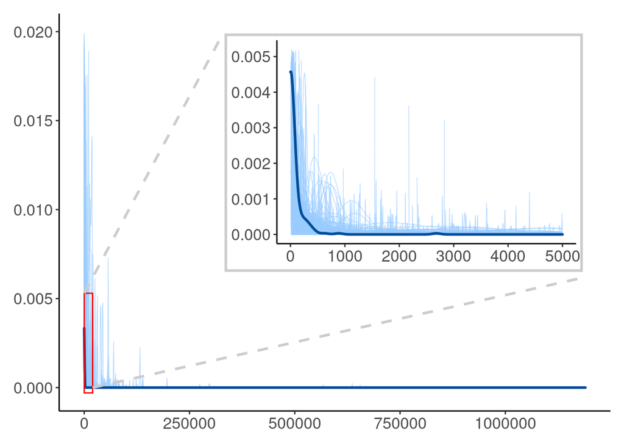

```r
# 组合图
combined_plot <- main_plt +
  inset_element(zoom_plt,
                left = 0.3, bottom = 0.35,
                right = 0.95, top = 0.95)

# 显示图
combined_plot
```

```r
ggsave(filename = "pp4.pdf", plot = combined_plot, device = "pdf", width = 6, height = 4)
```

The visualization of the prior prediction check is shown below. We can see that the sample size can accommodate values up to 1,200,000. And, the actual data fall within the range of the prior distribution, demonstrating the appropriateness of the prior.

# 5 Fit model

```r
gdp_zero_inflated_negbinomial_bts0 <- brms::brm(
   bf(bts_sample_size ~ 1,
      zi ~ 1),
  data = gdpdata,
  family = zero_inflated_negbinomial(),
  chains = 4, iter = 20000, warmup = 10000,
  cores = 4, seed = 1234,
  prior =
  set_prior("normal(6, 2.67)", class = "Intercept")+
  set_prior("inv_gamma(0.4, 0.3)", class = "shape")+
  set_prior("normal(0, 1)", class = "Intercept", dpar= "zi"),

  save_pars = save_pars(all = TRUE),
  control = list(adapt_delta = 0.99,  max_treedepth=10),
  backend = "cmdstanr",
  file = "gdp_zero_inflated_negbinomial_bts0"
)
gdp_zero_inflated_negbinomial_bts0
```

```
##  Family: zero_inflated_negbinomial
##   Links: mu = log; shape = identity; zi = logit
## Formula: bts_sample_size ~ 1
##          zi ~ 1
##    Data: gdpdata (Number of observations: 185)
##   Draws: 4 chains, each with iter = 20000; warmup = 10000; thin = 1;
##          total post-warmup draws = 40000
##
## Regression Coefficients:
##              Estimate Est.Error l-95% CI u-95% CI Rhat Bulk_ESS Tail_ESS
## Intercept        5.62      0.15     5.34     5.92 1.00    27820    23111
## zi_Intercept     1.19      0.17     0.86     1.54 1.00    31035    23808
##
## Further Distributional Parameters:
##       Estimate Est.Error l-95% CI u-95% CI Rhat Bulk_ESS Tail_ESS
## shape     1.16      0.24     0.73     1.68 1.00    28201    23288
##
## Draws were sampled using sample(hmc). For each parameter, Bulk_ESS
## and Tail_ESS are effective sample size measures, and Rhat is the potential
## scale reduction factor on split chains (at convergence, Rhat = 1).
```

```r
gdp_zero_inflated_negbinomial_bts1 <- brms::brm(
   bf(bts_sample_size ~ 1 + log_GDP_per_capita,
      zi ~ 1 ),
  data = gdpdata,
  family = zero_inflated_negbinomial(),
  chains = 4, iter = 20000, warmup = 10000,
  cores = 4, seed = 1234,
  prior =  set_prior("normal(0, 0.1 )", class = "b") +
  set_prior("normal(6, 2.67)", class = "Intercept")+
  set_prior("inv_gamma(0.4, 0.3)", class = "shape")+
  set_prior("normal(0, 1)", class = "Intercept", dpar= "zi"),

  save_pars = save_pars(all = TRUE),
  control = list(adapt_delta = 0.99,  max_treedepth=10),
  backend = "cmdstanr",
  file = "gdp_zero_inflated_negbinomial_bts1"
)
gdp_zero_inflated_negbinomial_bts1
```

```
##  Family: zero_inflated_negbinomial
##   Links: mu = log; shape = identity; zi = logit
## Formula: bts_sample_size ~ 1 + log_GDP_per_capita
##          zi ~ 1
##    Data: gdpdata (Number of observations: 185)
##   Draws: 4 chains, each with iter = 20000; warmup = 10000; thin = 1;
##          total post-warmup draws = 40000
##
## Regression Coefficients:
##                    Estimate Est.Error l-95% CI u-95% CI Rhat Bulk_ESS Tail_ESS
## Intercept              5.16      0.30     4.58     5.77 1.00    19617    21145
## zi_Intercept           1.19      0.17     0.86     1.54 1.00    29826    25036
## log_GDP_per_capita     0.14      0.08    -0.02     0.30 1.00    22075    24645
##
## Further Distributional Parameters:
##       Estimate Est.Error l-95% CI u-95% CI Rhat Bulk_ESS Tail_ESS
## shape     1.27      0.27     0.79     1.86 1.00    26782    22922
##
## Draws were sampled using sample(hmc). For each parameter, Bulk_ESS
## and Tail_ESS are effective sample size measures, and Rhat is the potential
## scale reduction factor on split chains (at convergence, Rhat = 1).
```

```r
gdp_zero_inflated_negbinomial_bts2 <- brms::brm(
   bf(bts_sample_size ~ 1 + log_GDP_per_capita,
      zi ~ 1 + log_GDP_per_capita),
  data = gdpdata,
  family = zero_inflated_negbinomial(),
  chains = 4, iter = 20000, warmup = 10000,
  cores = 4, seed = 1234,
 prior = set_prior("normal(0, 0.1 )", class = "b") +
         set_prior("normal(6, 2.67 )", class = "Intercept")+
        set_prior("inv_gamma(0.4, 0.3)", class = "shape")+
        set_prior("normal(0, 0.1)", class = "b", dpar= "zi") +
        set_prior("normal(0, 1)", class = "Intercept", dpar= "zi"),
  save_pars = save_pars(all = TRUE),
  control = list(adapt_delta = 0.99,  max_treedepth=10),
  backend = "cmdstanr",
  file = "gdp_zero_inflated_negbinomial_bts2"
)
gdp_zero_inflated_negbinomial_bts2
```

```
##  Family: zero_inflated_negbinomial
##   Links: mu = log; shape = identity; zi = logit
## Formula: bts_sample_size ~ 1 + log_GDP_per_capita
##          zi ~ 1 + log_GDP_per_capita
##    Data: gdpdata (Number of observations: 185)
##   Draws: 4 chains, each with iter = 20000; warmup = 10000; thin = 1;
##          total post-warmup draws = 40000
##
## Regression Coefficients:
##                       Estimate Est.Error l-95% CI u-95% CI Rhat Bulk_ESS
## Intercept                 5.16      0.30     4.59     5.77 1.00    21018
## zi_Intercept              1.76      0.25     1.28     2.25 1.00    30079
## log_GDP_per_capita        0.14      0.08    -0.02     0.30 1.00    24361
## zi_log_GDP_per_capita    -0.27      0.08    -0.42    -0.11 1.00    32938
##                       Tail_ESS
## Intercept                21472
## zi_Intercept             25473
## log_GDP_per_capita       24455
## zi_log_GDP_per_capita    26035
##
## Further Distributional Parameters:
##       Estimate Est.Error l-95% CI u-95% CI Rhat Bulk_ESS Tail_ESS
## shape     1.28      0.27     0.80     1.86 1.00    31110    25444
##
## Draws were sampled using sample(hmc). For each parameter, Bulk_ESS
## and Tail_ESS are effective sample size measures, and Rhat is the potential
## scale reduction factor on split chains (at convergence, Rhat = 1).
```

```r
# Extract the highest density interval (HDI)
library(bayestestR)
# Extract posterior samples
posterior_samples <- as.data.frame(gdp_zero_inflated_negbinomial_bts2)

# Extract median
posterior_medians <- apply(posterior_samples, 2, median)

# Extract HDI
hdi_values <- hdi(posterior_samples, ci = 0.95)

# Integration results
result_df <- data.frame(
  Parameter = names(posterior_medians),
  Median = posterior_medians,
  HDI_Lower = hdi_values$CI_low,
  HDI_Upper = hdi_values$CI_high
)


result_df
```

```
##                                       Parameter       Median    HDI_Lower
## b_Intercept                         b_Intercept    5.1520750    4.5686400
## b_zi_Intercept                   b_zi_Intercept    1.7539100    1.2710200
## b_log_GDP_per_capita       b_log_GDP_per_capita    0.1391225   -0.0189481
## b_zi_log_GDP_per_capita b_zi_log_GDP_per_capita   -0.2654330   -0.4186910
## shape                                     shape    1.2555950    0.7696770
## Intercept                             Intercept    5.4263300    5.0912400
## Intercept_zi                       Intercept_zi    1.2303100    0.8950450
## lprior                                   lprior   -7.5239450  -12.7037000
## lp__                                       lp__ -373.5460000 -376.9750000
##                           HDI_Upper
## b_Intercept                5.747400
## b_zi_Intercept             2.243300
## b_log_GDP_per_capita       0.299488
## b_zi_log_GDP_per_capita   -0.111077
## shape                      1.818450
## Intercept                  5.786660
## Intercept_zi               1.579310
## lprior                    -3.284400
## lp__                    -371.488000
```

```r
posterior_interval(gdp_zero_inflated_negbinomial_bts2, prob = 0.95)
```

```
##                                  2.5%        97.5%
## b_Intercept                4.58986050    5.7745140
## b_zi_Intercept             1.28009850    2.2539050
## b_log_GDP_per_capita      -0.02398042    0.2951983
## b_zi_log_GDP_per_capita   -0.42208580   -0.1138678
## shape                      0.80081370    1.8619125
## Intercept                  5.09840975    5.7961108
## Intercept_zi               0.90012583    1.5856205
## lprior                   -13.55241250   -3.8087097
## lp__                    -377.79802500 -371.7780000
```

```r
bayestestR::hdi(gdp_zero_inflated_negbinomial_bts2, component = c("all"),ci = 0.95)
```

```
## Highest Density Interval
##
## Parameter          |        95% HDI
## -----------------------------------
## (Intercept)        | [ 4.57,  5.75]
## log_GDP_per_capita | [-0.02,  0.30]
##
## # Fixed effects distributional
##
## Parameter |        95% HDI
## --------------------------
## shape     | [ 0.77,  1.82]
##
## # Fixed effects (zero-inflated)
##
## Parameter          |        95% HDI
## -----------------------------------
## (Intercept)        | [ 1.27,  2.24]
## log_GDP_per_capita | [-0.42, -0.11]
```

```r
bayestestR::ci(gdp_zero_inflated_negbinomial_bts2, component = c("all"),ci = 0.95)
```

```
## Equal-Tailed Interval
##
## Parameter               |        95% ETI | Effects |      Component
## -------------------------------------------------------------------
## b_Intercept             | [ 4.59,  5.77] |   fixed |    conditional
## b_log_GDP_per_capita    | [-0.02,  0.30] |   fixed |    conditional
## b_zi_Intercept          | [ 1.28,  2.25] |   fixed |  zero_inflated
## b_zi_log_GDP_per_capita | [-0.42, -0.11] |   fixed |  zero_inflated
## shape                   | [ 0.80,  1.86] |   fixed | distributional
```

### Interpreting results

$$Var(Y\mid \mu ,\phi )= \mu +\frac{\mu
^{2} }{\phi }$$

# 6 Posterior prediction check

First, as shown in panel (a) below, the actual data are well contained within the posterior predictive distribution. In addition, panels (b) and (c) show that the minimum and mean values of the actual data are close to the center of the posterior predictive distribution. In panel (d), although the maximum value of 2,682 is an outlier (as all other values are below 1,000) and does not fall exactly in the center of the posterior predictive distribution, the distribution adequately covers this extreme value and is therefore acceptable. Overall, this indicates that our model effectively describes the actual data.

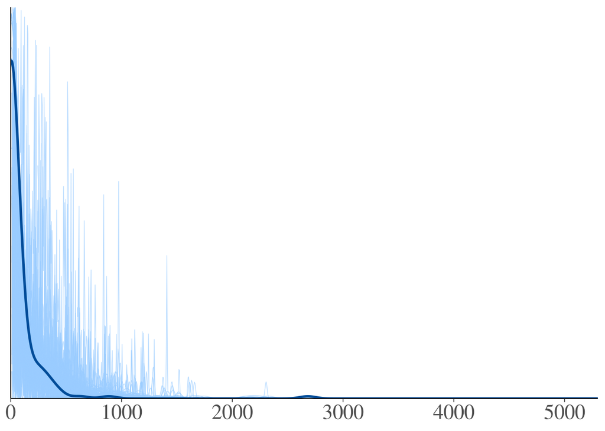

```r
pp_check(gdp_zero_inflated_negbinomial_bts2, ndraws = 200)+
  xlim(0, 5300) +
  ylim(0, 0.0053) +
theme(
    text = element_text(size = 22),
    plot.title = element_text(hjust = .5),
    panel.grid.major = element_blank(),
    panel.grid.minor = element_blank(),
    panel.border = element_blank(),
    strip.background =element_blank(),
    axis.line.x.bottom = element_line(color = 'black'),
    axis.line.y.left   = element_line(color = 'black'),
    legend.position = "none")
```

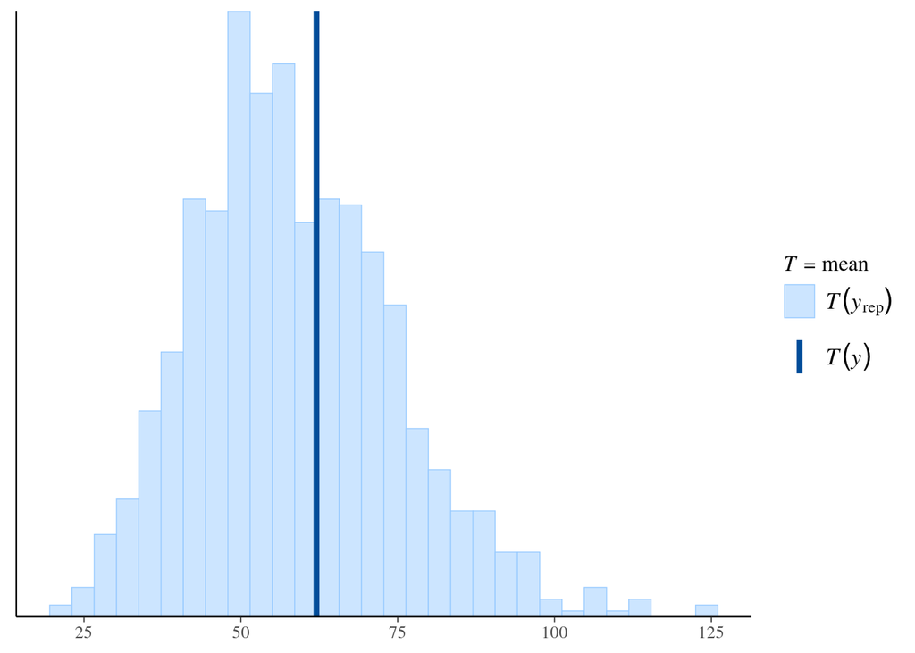

```r
 # Extract posterior prediction samples from the fitting model
posterior_preds <- posterior_predict(gdp_zero_inflated_negbinomial_bts2, ndraws = 1000)

y = gdpdata$bts_sample_size
#posterior_preds <- t(posterior_preds)
y_df <- as.data.frame(y)

posterior_preds_df <- as.data.frame(posterior_preds)

 ppc_stat(gdp_zero_inflated_negbinomial_bts2,y = y, yrep = posterior_preds,
 stat = "mean")
```

```r
 ppc_stat(gdp_zero_inflated_negbinomial_bts2,y = y, yrep = posterior_preds,
 stat = "min")
```

[figure not shown]

```r
 ppc_stat(gdp_zero_inflated_negbinomial_bts2,y = y, yrep = posterior_preds,
 stat = "max")
```

[figure not shown]

# Country level drawing

## GDP_per_capita drawing

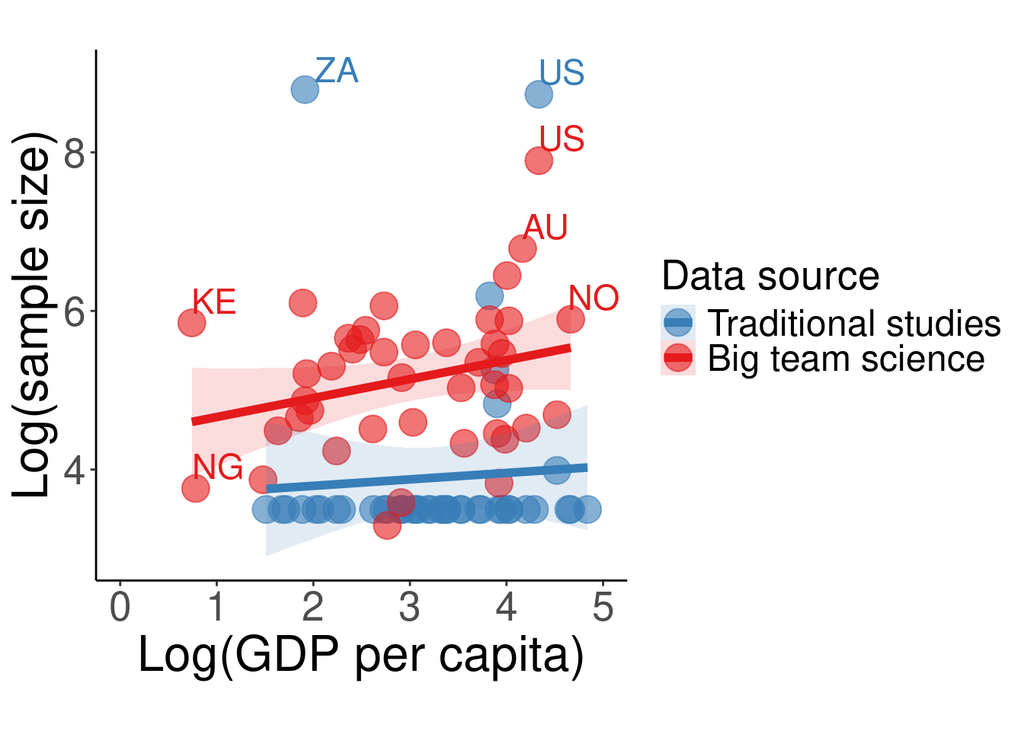

```r
gdpdata$log_ps_sample_size[is.infinite(gdpdata$log_ps_sample_size)] <- NA
gdpdata$log_bts_sample_size[is.infinite(gdpdata$log_bts_sample_size)] <- NA

combined_data2 <- rbind(
  transform(gdpdata, source = "PS2014", value = log_ps_sample_size),
  transform(gdpdata, source = "PSA001", value = log_bts_sample_size)
)

gdp1 <- ggplot(combined_data2, aes(x = log_GDP_per_capita, y = value, color = source, fill = source)) +

  geom_point(size = 6, alpha = 0.6) +
  geom_smooth(method = "lm",size = 2, alpha = 0.15) +

  scale_color_manual(name = "Data source",
                     values = c("#377EB8", "#E41A1C"),
                     labels = c("Traditional studies", "Big team science")) +
  scale_fill_manual(name = "Data source",
                    values = c("#377EB8", "#E41A1C"),
                    labels = c("Traditional studies", "Big team science")) +
  geom_text_repel(data = combined_data2, aes(label = country_2), max.overlaps=2,label.padding=5,
                   family = "sans", size = 6,
                  nudge_y = 0.2,  # Adjust the position of the label on the y-axis
                  nudge_x = 0.2,
                show.legend = FALSE) +
  ylab("Log(sample size)") +
  xlab("Log(GDP per capita)") +
  theme(axis.text = element_text(size = 20),
        axis.title = element_text(size = 24),
        panel.background = element_rect(fill = "white"),
        axis.line = element_line(color = "black"),
        aspect.ratio = 1,
        legend.position = "right",
        legend.text = element_text(size = 18),
        legend.title = element_text(size = 20)) +
  xlim(c(0, 5)) +
  guides(color = guide_legend(override.aes = list(linetype = c("solid", "dashed"))))
gdp1
```

```r
# Save for PDF
#ggsave(filename = "GDP.pdf", plot = gdp1, device = "pdf", width = 12, height = 12)
```